# Sanity checks/tests

David Pinho

2020-09-10

These are just some small tests to make sure that the output is the one expected. I also did a lot of manual testing for the functions, so I are working as intended *for the parameters I use*. Everything else doesn't come with the warranty.

## Import data

```r
library(tidyverse)
library(data.table)
```

```r
library(ggplot2)
```

```r
# Importing global variables/scripts
path_global_variables <- here::here('/R_exec/ftse100/global_variables.R')
invisible(source(path_global_variables))
script_names <- list.files(path=path_r_scripts, pattern="*.R$", full.names=TRUE)
invisible(lapply(script_names, FUN=source))

# Importing some data
invisible(source(path_import_vars))
data.table::setDTthreads(threads=5)  # Change this if you are running on another PC

# Getting all the other data
rv_ind_oos <- realised_measures$rv_5[start_forecast:NROW(realised_measures)]
rv_cv_oos <- realised_measures$rv_5[(start_forecast+start_comb_forecast_cv):NROW(realised_measures)]
rv_all_oos <- realised_measures$rv_5[(
    start_forecast+start_comb_forecast_cv+start_comb_forecast):NROW(realised_measures)]

# Getting results
data_all_forecasts_raw <- join_and_adjust_all_data(path_ind=path_results, path_comb=path_comb_results,
                                               sum_to_date_int=start_forecast, regex='csv')
data_all_forecasts_matrix <- data_all_forecasts_raw %>%
    dplyr::filter(date_int >= (start_forecast+start_comb_forecast_cv+start_comb_forecast)) %>%
    dplyr::select(date_int, model_name, vol) %>%
    tidyr::pivot_wider(names_from=model_name, values_from=vol) %>%
    dplyr::select(-date_int)
```

Does every model have 1004 observations?

```r
print(NROW(data_all_forecasts_matrix) == 1004)
```

```
## [1] TRUE
```

```r
print(NCOL(data_all_forecasts_matrix) == 250)
```

```
## [1] TRUE
```

```r
print(sum(is.na(data_all_forecasts_matrix)) == 0)
```

```
## [1] TRUE
```

## Summary statistics

Which forecasts are equal to or smaller than 0? And does my function solve the problem as expected?

```r
odd_obs <- data_all_forecasts_matrix <= 0
models_0 <- colSums(odd_obs)
print(models_0[models_0 > 0])
```

```
##                          arima-0-0-1-rv-ML
##                                          2
##                 arima-0-0-1-squared_ret-ML
##                                          2
##  har-c(1, 5, 22)-c(1, 5, 22)-1-NA-NA-FALSE
##                                          1
## har-c(1, 5, 22)-c(1, 5, 22)-NA-NA-NA-FALSE
##                                          1
##           har-c(1, 5, 22)-NA-1-NA-NA-FALSE
##                                          1
##      har-c(5, 22)-c(1, 5, 22)-1-NA-1-FALSE
##                                          3
##     har-c(5, 22)-c(1, 5, 22)-NA-NA-1-FALSE
##                                          3
##               har-c(5, 22)-NA-1-NA-1-FALSE
##                                          2
##           har-NA-NA-1-c(1, 5, 22)-NA-FALSE
##                                          1
##               har-NA-NA-1-c(5, 22)-1-FALSE
##                                          2
```

```r
corrected_matrix <- apply(X=data_all_forecasts_matrix, FUN=replace_negative_predictions,
                          MARGIN=2)
print(colSums(is.na(corrected_matrix))[models_0>0])
```

```
##                          arima-0-0-1-rv-ML
##                                          0
##                 arima-0-0-1-squared_ret-ML
##                                          0
##  har-c(1, 5, 22)-c(1, 5, 22)-1-NA-NA-FALSE
##                                          0
## har-c(1, 5, 22)-c(1, 5, 22)-NA-NA-NA-FALSE
##                                          0
##           har-c(1, 5, 22)-NA-1-NA-NA-FALSE
##                                          0
##      har-c(5, 22)-c(1, 5, 22)-1-NA-1-FALSE
##                                          0
##     har-c(5, 22)-c(1, 5, 22)-NA-NA-1-FALSE
##                                          0
##               har-c(5, 22)-NA-1-NA-1-FALSE
##                                          0
##           har-NA-NA-1-c(1, 5, 22)-NA-FALSE
##                                          0
##               har-NA-NA-1-c(5, 22)-1-FALSE
##                                          0
```

```r
print(corrected_matrix[which(odd_obs)] == (corrected_matrix[which(odd_obs)-1]/2))
```

```
##  [1] TRUE TRUE TRUE TRUE TRUE TRUE TRUE TRUE TRUE TRUE TRUE TRUE TRUE TRUE TRUE
## [16] TRUE TRUE TRUE
```

Does any model have a weird number of observations?

```r
possible_values <- c(NROW(realised_measures$rv_5) - start_forecast +1 ,
                     NROW(realised_measures$rv_5) - (start_forecast+start_comb_forecast_cv) + 1,
                     NROW(realised_measures$rv_5) - (start_forecast+start_comb_forecast_cv+start_comb_forecast)+1)
n_obs <- data_all_forecasts_raw %>%
    group_by(model_name) %>%
    summarise(n_obs = NROW(na.omit(vol))) %>%
    count(n_obs)
print(n_obs)
```

```
## # A tibble: 3 x 2
##   n_obs     n
##   <int> <int>
## 1  1253   176
## 2  1503    33
## 3  2733    41
```

```r
print(n_obs$n_obs %in% possible_values)
```

```
## [1]  TRUE  TRUE FALSE
```

The 41 values of '2733' are due to naive models, which exclude the first observation in my case:

```r
data_all_forecasts_raw %>%
    filter((family == 'naive-iv')|(family == 'naive-rv5')|(family == 'naive-squared_ret')) %>%
    group_by(model_name) %>%
    summarise(n_obs = NROW(na.omit(vol))) %>%
    count(n_obs)
```

| n_obs | n |
| --- | --- |
| 2733 | 41 |

Do all model categories have the correct number of observations?

```r
data_all_forecasts_raw %>%
    group_by(family) %>%
    summarise(n_models = NROW(unique(model_name)))
```

| family | n_models |
| --- | --- |
| arima-rv | 3 |
| arima-squared_ret | 3 |
| equal_weight | 1 |
| garch | 14 |
| group | 127 |
| har | 13 |
| naive-iv | 1 |
| naive-rv5 | 20 |
| naive-squared_ret | 20 |
| regularization-mse | 3 |

[output cut: 3 more lines]

## Verifying individual models

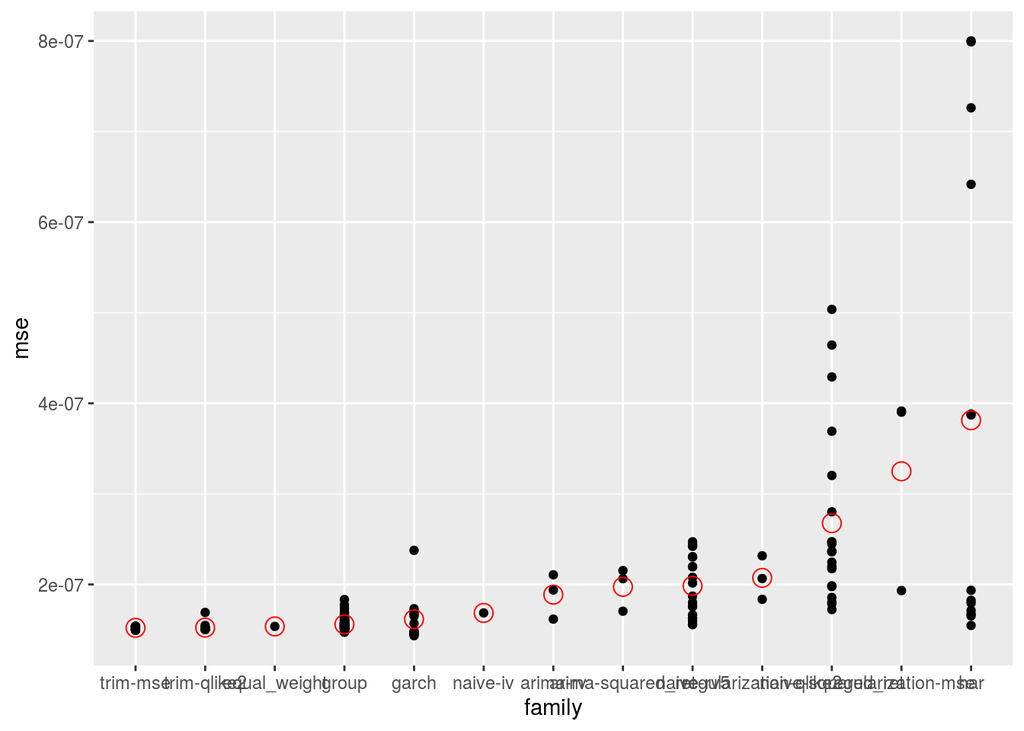

```r
data_anomaly_plot <- data_all_forecasts_raw %>%
    filter(date_int >= (start_forecast+start_comb_forecast+start_comb_forecast_cv)) %>%
    dplyr::select(date_int, model_name, family, vol) %>%
    group_by(model_name) %>%
    mutate(error_squared = (vol - rv_all_oos)^2) %>%
    ungroup()
data_anomaly_plot_clean <-data_anomaly_plot %>%
    group_by(model_name) %>%
    summarise(mse = mean(error_squared), family=as.factor(family[1])) %>%
    mutate(family = fct_reorder(.f=family, .x=mse, .fun=mean))

data_anomaly_plot_clean %>%
    ggplot(aes(family, mse)) +
    geom_point() +
    geom_point(data=data_anomaly_plot_clean %>% group_by(family) %>% summarise(mse = mean(mse)),
               aes(family, mse), color='red', shape=1, size=4)
```

First I want to check that all 13 HAR function are using the necessary parameters (they are).

```r
# Importing in-sample results
path_har_insample <- list.files(path=path_results_fit, pattern='har', full.names = TRUE)
model_names <- lapply(X=str_split(path_har_insample, pattern = '//'), FUN=last) %>% unlist
har_insample <- lapply(X=path_har_insample, FUN=function (x) get(load(x)))
for (i in 1:length(har_insample)) {
    print(model_names[i])
    print(har_insample[[i]])
    print("\n\n")
}
```

```
## [1] "har-c(1, 5, 22)-1-c(1, 5, 22)-NA-NA_20200713_143532"
##
## Call:
## lm(formula = rv_response ~ predictors)
##
## Coefficients:
##      alpha        rv_1        rv_5       rv_22         j_1         j_5
##  1.351e-05   3.220e-01  -2.232e-01   2.319e-01   4.624e-01   1.382e+00
##       j_22     q._rv_1
## -4.781e-01  -3.131e+01
##
## [1] "\n\n"
## [1] "har-c(1, 5, 22)-1-NA-NA-NA_20200713_143454"
##
## Call:
## lm(formula = rv_response ~ predictors)
##
## Coefficients:
##      alpha        rv_1        rv_5       rv_22     q._rv_1
##  9.958e-06   5.740e-01   2.517e-01   1.350e-01  -5.327e+01
##
## [1] "\n\n"
## [1] "har-c(1, 5, 22)-NA-c(1, 5, 22)-NA-NA_20200713_143453"
##
## Call:
## lm(formula = rv_response ~ predictors)
##
## Coefficients:
##      alpha        rv_1        rv_5       rv_22         j_1         j_5
##  1.768e-05  -8.475e-03  -2.130e-01   2.253e-01   9.592e-01   1.428e+00
##       j_22
## -3.987e-01
##
## [1] "\n\n"
## [1] "har-c(1, 5, 22)-NA-c(1, 5, 22)-NA-NA_20200717_005648"
##
## Call:
## lm(formula = rv_response ~ predictors)
##
## Coefficients:
```

[output cut: 89 more lines]

```
## Coefficients:
##     alpha        c_1        c_5       c_22
## 1.985e-05  2.119e-01  5.552e-01  6.791e-01
##
## [1] "\n\n"
## [1] "har-NA-NA-NA-c(5, 22)-1_20200713_143812"
##
## Call:
## lm(formula = rv_response ~ predictors)
##
## Coefficients:
##      alpha         c_5        c_22     s-pos_1     s-neg_1
##  1.851e-05   4.283e-01   6.366e-01  -2.357e-03   4.550e-01
##
## [1] "\n\n"
```

Now I want to manually replicate one of the results of the most complicated HAR model, which is the QS-HAR-C-J.

```r
# 1 day measures
rv1 <- realised_measures$rv_5
c1 <- realised_measures$trv_5
j1 <- rv1 - c1
q1 <- realised_measures$rq_5
s_neg1 <- realised_measures$rsv_5
s_pos1 <- realised_measures$rv_5 - s_neg1
q.s_neg1 <- s_neg1 * q1^(1/2)
q.s_pos1 <- s_pos1 * q1^(1/2)
# 5 day measures
c5 <- zoo::rollapply(data=c1, width=5, FUN=mean, partial=FALSE,
                     align='right', fill=NA)
j5 <- zoo::rollapply(data=j1, width=5, FUN=mean, partial=FALSE,
                     align='right', fill=NA)
# 22 day measures
c22 <- zoo::rollapply(data=c1, width=22, FUN=mean, partial=FALSE,
                      align='right', fill=NA)
j22 <- zoo::rollapply(data=j1, width=22, FUN=mean, partial=FALSE,
                      align='right', fill=NA)
# all measures
har_test_measures <- data.frame(alpha=1, s_neg1 = s_neg1, s_pos1 = s_pos1,
                                q.s_pos1 = q.s_pos1, q.s_neg1 = q.s_neg1,
                                j1 = j1, j5 = j5, j22 = j22,
                                c5 = c5, c22 = c22)

har_forecasts <- vector(mode='list', length=1004)
start_oos_forecast <- start_forecast+start_comb_forecast_cv+start_comb_forecast
for (t in start_oos_forecast:NROW(rv_xts)) {
    fit <- lm(rv_xts[2:(t-1)] ~ as.matrix(har_test_measures[1:(t-2), ])-1)
    forecast_t <- fit$coefficients %*% t(har_test_measures[(t-1), ])
    har_forecasts[[t]] <- as.numeric(forecast_t)
}
har_forecasts <- unlist(har_forecasts)
```

Now I compare the forecasts and I get the same results.

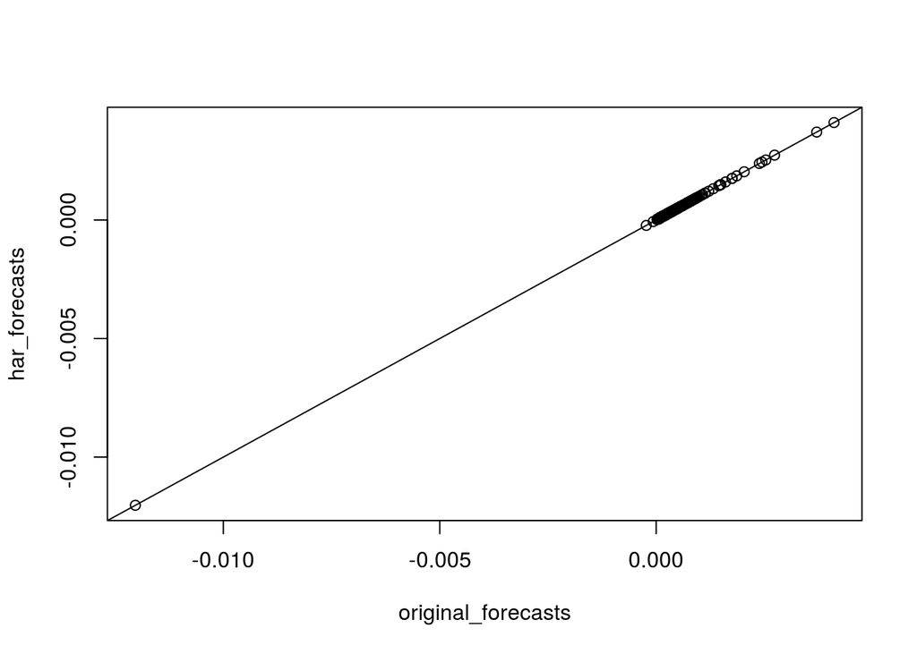

```r
original_forecasts <- data_all_forecasts_raw %>%
    filter(date_int >= start_oos_forecast,
           model_name == 'har-c(5, 22)-c(1, 5, 22)-1-NA-1-FALSE')  %>%
    dplyr::select(vol) %>%
    unlist

plot(original_forecasts, har_forecasts)
abline(a=0, b=1)
```

```r
print((har_forecasts - rv_all_oos)^2 %>% mean)
```

```
## [1] 3.871118e-07
```

```r
print((original_forecasts - rv_all_oos)^2 %>% mean)
```

```
## [1] 3.871118e-07
```

I can also use the HAR function to create an AR(1) model, which also gives me the expected results.

```r
har_test_measures <- data.frame(alpha=1, rv1=rv1)
har_forecasts <- vector(mode='list', length=1004)
start_oos_forecast <- start_forecast+start_comb_forecast_cv+start_comb_forecast
for (t in start_oos_forecast:NROW(rv_xts)) {
    fit <- lm(rv_xts[2:(t-1)] ~ as.matrix(har_test_measures[1:(t-2), ])-1)
    forecast_t <- fit$coefficients %*% t(har_test_measures[(t-1), ])
    har_forecasts[[t]] <- as.numeric(forecast_t)
}
har_forecasts <- unlist(har_forecasts)
```

Comparison (they are not exactly the same because one is estimated with OLS, the other with maximum likelihood, so there's a tiny rounding error):

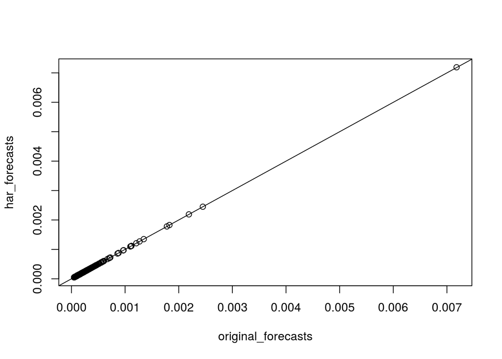

```r
original_forecasts <- data_all_forecasts_raw %>%
    filter(date_int >= start_oos_forecast,
           model_name == 'arima-1-0-0-rv-ML')  %>%
    dplyr::select(vol) %>%
    unlist

plot(original_forecasts, har_forecasts)
abline(a=0, b=1)
```

```r
print((har_forecasts - rv_all_oos)^2 %>% mean)
```

```
## [1] 1.939325e-07
```

```r
print((original_forecasts - rv_all_oos)^2 %>% mean)
```

```
## [1] 1.938644e-07
```

And, lastly, here's a simpler version of the GARCH.

```r
spec <- rugarch::ugarchspec(
        variance.model=list(model='sGARCH', garchOrder=c(1, 1)),
        mean.model=list(armaOrder=c(0, 0), archm=FALSE,
                        include.mean=FALSE),
        distribution.model='norm')
garch_forecasts <- vector(mode='list', length=1004)
for (t in start_oos_forecast:NROW(returns_xts)) {
    garch_fit <- rugarch::ugarchfit(spec=spec, data=returns_xts[1:(t-1)])
    garch_forecast_t <- rugarch::ugarchforecast(fit=garch_fit, data=returns_xts[1:(t-1)], n.ahead=1)
    garch_forecasts[[t]] <- garch_forecast_t@forecast$sigmaFor[[1]]^2
}
garch_forecasts <- unlist(garch_forecasts)
```

Once again, only has some tiny rounding errors.

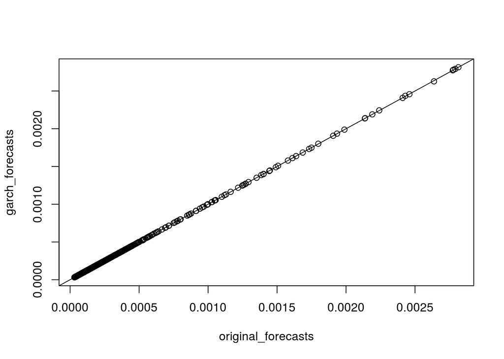

```r
original_forecasts <- data_all_forecasts_raw %>%
    filter(date_int >= start_oos_forecast,
           model_name == 'fGARCH-GARCH-1-1-0-0-FALSE-FALSE-norm')  %>%
    dplyr::select(vol) %>%
    unlist

plot(original_forecasts, garch_forecasts)
abline(a=0, b=1)
```

```r
print((garch_forecasts - rv_all_oos)^2 %>% mean)
```

```
## [1] 1.708573e-07
```

```r
print((original_forecasts - rv_all_oos)^2 %>% mean)
```

```
## [1] 1.708607e-07
```

## Verifying model comparisons

For the regularization, the results are very bad for the best models.

```r
# all measures
data_reg_test <- data_all_forecasts_raw %>%
    dplyr::filter(date_int >= start_forecast,
                  ind_or_comb == 'ind') %>%
    dplyr::select(date_int, model_name, vol) %>%
    tidyr::pivot_wider(names_from=model_name, values_from=vol) %>%
    dplyr::select(-date_int)
data_reg_test <- apply(X=data_reg_test, FUN=replace_negative_predictions, MARGIN=2)
lambda_params <- exp(seq(from=-12, -28, length.out=81))  # Has to be in descending order
reg_forecasts <- matrix(data=NA, nrow=NROW(rv_ind_oos), ncol=length(lambda_params))
set.seed(1)
for (t in (start_comb_forecast_cv+1):(NROW(rv_ind_oos))) {
    # Here we do not need to lag data_reg_test because we would have the estimated forecast
    # of t-1 at t-2 -- the data is already matched.
    glmnet_fit <- glmnet::glmnet(alpha=0, family = 'gaussian',
                          y=as.matrix(rv_ind_oos[1:(t-1)]), x=as.matrix(data_reg_test[1:(t-1), ]),
                          standardize = FALSE, standardize.response = FALSE,
                          lambda=lambda_params, maxit=10^8)
    glmnet_forecast_t <- glmnet::predict.glmnet(object=glmnet_fit,
                                              newx=as.matrix(data_reg_test[t, , drop=FALSE]))
    reg_forecasts[t, ] <- glmnet_forecast_t
}
reg_forecasts <- na.omit(reg_forecasts)
```

```r
reg_results_serror <- reg_forecasts %>%
    apply(X=., FUN=function (x) ((x - rv_cv_oos)^2), MARGIN=2)
cerror <- reg_results_serror %>%
    as.data.frame() %>%
    roll_matrix_mean(matrix=., na.rm = TRUE) %>%
    lag_columns(as_matrix=FALSE)
for (row in 1:NROW(cerror)) {
    if (sum(is.na(cerror[row, ])) == 0) {
        cerror[row, ] <- rank(cerror[row, ], ties.method='random')
    }
}
weights <- ((cerror == 1)*1)
pred <- rowSums(reg_forecasts * weights)
```

This is the only situation where the results are very different from other cases. The code is almost identical to the one I use, and the data is the same. The differences seem to be due to the quirks/instability of the algorithm. There are 8 anomalies for the ridge, although the LASSO has a few more.

```r
(pred[(start_comb_forecast+1):NROW(pred)] - rv_all_oos)^2 %>% mean
```

```
## [1] 1.929298e-07
```

```r
data_all_forecasts_raw %>%
    filter(model_name == 'lasso-mse', date_int >= (start_oos_forecast)) %>%
    mutate(y = rv_all_oos,
           serr = (vol-y)^2) %>%
    summarise(mean(serr))
```

| mean(serr) |
| --- |
| 3.901881e-07 |

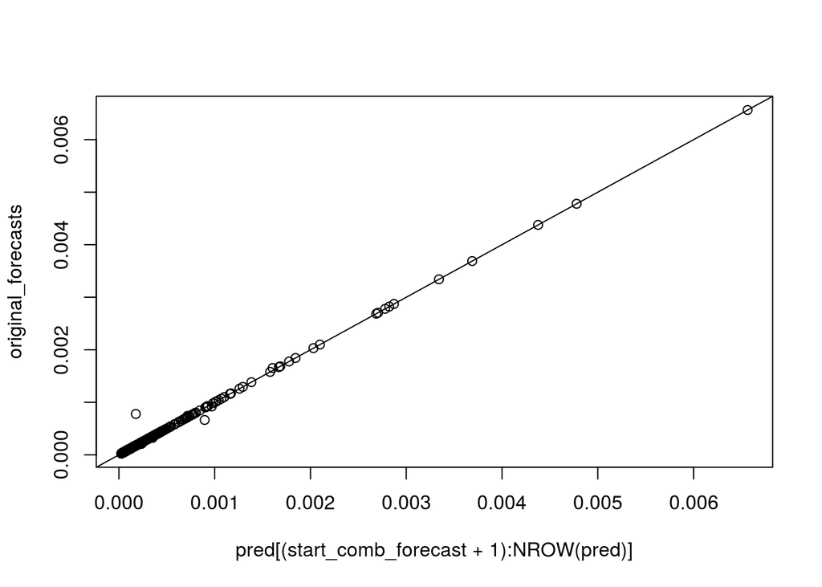

```r
original_forecasts <- data_all_forecasts_raw %>%
    filter(model_name == 'ridge-mse', date_int >= (start_oos_forecast)) %>%
    dplyr::select(vol) %>%
    unlist
plot(pred[(start_comb_forecast+1):NROW(pred)], original_forecasts)
abline(a=0, b=1)
```

```r
which(pred[(start_comb_forecast+1):NROW(pred)] != original_forecasts)
```

```
## vol435 vol437 vol438 vol439 vol441 vol445 vol446 vol465
##    435    437    438    439    441    445    446    465
```

For trimming:

```r
trimming_ind_matrix <- data_all_forecasts_raw %>%
    filter(ind_or_comb == 'ind',
           date_int >= (start_forecast)) %>%
    dplyr::select(date_int, model_name, vol) %>%
    tidyr::pivot_wider(names_from=model_name, values_from=vol) %>%
    dplyr::select(-date_int)
trim_error <- trimming_ind_matrix %>%
    apply(X=., FUN=function (x) ((x - rv_ind_oos)^2), MARGIN=2)
cerror <- trim_error %>%
    as.data.frame() %>%
    roll_matrix_mean(matrix=., na.rm = TRUE) %>%
    lag_columns(as_matrix=FALSE)
k <- 1.1
weights <- matrix(data=NA, nrow=NROW(cerror), ncol=NCOL(cerror))
for (row in 1:NROW(cerror)) {
    if (sum(is.na(cerror[row, ])) == 0) {
        # row <- 2
        min_cerror <- which(rank(cerror[row, ], ties.method='random') == 1)
        weights[row, ] <- ((cerror[row, ]/as.numeric(cerror[row, ][min_cerror])) < k)*1
        weights[row, ] <- weights[row, ]/sum(weights[row, ])
    }
}
best_pred <- (trimming_ind_matrix * weights) %>% rowSums()
```

Another with tiny differences due to rounding error.

```r
original_forecasts <- data_all_forecasts_raw %>%
    filter(model_name == 'trim-1.1-mse', date_int >= (start_oos_forecast)) %>%
    dplyr::select(vol) %>%
    unlist
(best_pred[(start_comb_forecast_cv+start_comb_forecast+1):NROW(best_pred)] - rv_all_oos)^2 %>% mean
```

```
## [1] 1.493019e-07
```

```r
(original_forecasts - rv_all_oos)^2 %>% mean
```

```
## [1] 1.492545e-07
```

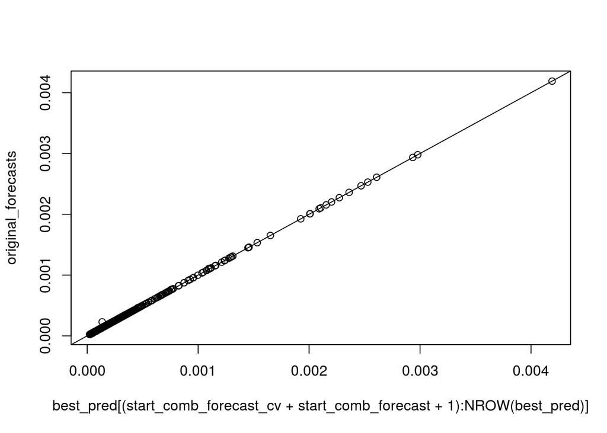

```r
plot(best_pred[(start_comb_forecast_cv+start_comb_forecast+1):NROW(best_pred)], original_forecasts)
abline(a=0, b=1)
```